# Recession Indicators

Brian Howard

March 5, 2017

# Introduction

Wouldn’t it be fun to see into future? I think so. For one of my machine learning classes we had a project that consumed financial data. I have extended that project to use machine learning to see if an indicator, or predictor, can be found that identifies market tops that occur prior to recessions. Then I use the model to build a trading strategy and backtest it to see how it performs.

# Get Economic and Financial Data

Data is pulled from several sources include FRED, yahoo, and Google. The code below shows an example that pulls in the consumer price index (CPI) from the FRED.

```r
# Consumer Price Index for All Urban Consumers: All Items
getSymbols("CPIAUCSL",src="FRED", auto.assign=TRUE)
```

```
## [1] "CPIAUCSL"
```

Since it is tedious to do this one at a time, all the symbols were entered into a data frame, loaded, and aggregated together in a single `xts` object. This is the complete list of symbol names and sources used in the project.

[output not shown]

## Feature Extraction

With the raw data downloaded, some of the interesting features can be extracted. The first step is reconcile the time intervals. Some of the data is released monthly and some daily. I chose to interpolate all data to a daily interval. The first section of code adds the daily rows to the dataframe.

```r
xtsData <- get(dfSyms$Symbol[1])
for(idx in 2:nrow(dfSyms)){
  xtsData <- merge(xtsData,  get(dfSyms$Symbol[idx]) )
}

dfData <- data.frame(xtsData)

# These two lines evenly space all the data at a daily interval
zooData <- zoo(dfData, as.Date(rownames(dfData)))
zooData <- merge(zooData, zoo(,seq(start(zooData), end(zooData), by=1)), all=TRUE)
dfData <- data.frame(zooData)
```

This section here does the interpolation (for continuous) or carries it forward (binary data)

```r
# The recession data is binary and needs to be carried forward
dfData$USREC <- na.locf(dfData$USREC)

dfData$CPIAUCSL <- na.approx(dfData$CPIAUCSL, rule=2)

dfData$UNRATE <- na.approx(dfData$UNRATE, rule=2)
dfData$GSPC.Open <- na.approx(dfData$GSPC.Open, rule=2)
dfData$NOBL.Open <- na.approx(dfData$NOBL.Open, rule=2)
dfData$INDPRO <- na.approx(dfData$INDPRO, rule=2)
dfData$W875RX1A020NBEA <- na.approx(dfData$W875RX1A020NBEA, rule=2)
dfData$PCOPPUSDM <- na.approx(dfData$PCOPPUSDM, rule=2)
dfData$BUSLOANS <- na.approx(dfData$BUSLOANS, rule =2)
dfData$NCBDBIQ027S <- na.approx(dfData$NCBDBIQ027S, rule = 2 )

dfData$RSALESAGG <- rowMeans(dfData[,c("RRSFS", "RSALES")], na.rm=TRUE)
dfSyms <- rbind(dfSyms, data.frame(Symbol="RSALESAGG", Source="Calc",
              Desc="Real Retail and Food Services Sales (RRSFS and RSALES)",
              yLabel ="Millions of Dollars" ) )
dfData$RSALESAGG <- na.approx(dfData$RSALESAGG, rule=2)
dfData$NCBDBIQ027S <- na.approx(dfData$NCBDBIQ027S, rule=2)
dfData$BUSLOANS <- na.approx(dfData$BUSLOANS, rule=2)
dfData$REALLNNSA <- na.approx(dfData$REALLNNSA, rule=2)
dfData$CONSUMERNSA <- na.approx(dfData$CONSUMERNSA, rule = 2)

dfData$TOTLNNSA <- (dfData$BUSLOANS+dfData$REALLNNSA+dfData$CONSUMERNSA)
dfSyms <- rbind(dfSyms, data.frame(Symbol="TOTLNNSA", Source="Calc",
              Desc="Total Loans Not Seasonally\nAdjusted (BUSLOANS+REALLNSA+CONSUMERNSA)",
              yLabel ="Billions of U.S. Dollars" ) )

dfData$DGS10 <- na.approx(dfData$DGS10, rule=2)
dfData$DGS1 <- na.approx(dfData$DGS1, rule=2)

dfData$DGS10TO1 <- dfData$DGS10-dfData$DGS1
dfSyms <- rbind(dfSyms, data.frame(Symbol="DGS10TO1", Source="Calc",
              Desc="Yield Curve, 10 and 1 Year Treasury (DGS10-DGS1)",
              yLabel ="Percent" ) )

dfData$ALTSALES <- na.approx(dfData$ALTSALES, rule = 2)
dfData$ICSA <- na.approx(dfData$ICSA, rule = 2)
dfData$GDP <- na.approx(dfData$GDP, rule = 2)
dfData$GDPC1 <- na.approx(dfData$GDPC1, rule = 2)
```

Year over year and smoothed derivative trends tend to smooth out seasonal variation. It gets used so often that I do this for every series downloaded.

```r
for (strName in names(dfData)){
  strNameYoY <- paste(strName,"_YoY",sep="")
  dfData[strNameYoY] <- CalcYoY(dfData, strName, 365)

  strRootSym <- strName
  strSuffix <- ""
  if( grepl("\\.", strName)){
    strRootSym <-  substr(strName, 1, regexpr("\\.", strName)-1)
    strSuffix <- substr(strName, regexpr("\\.", strName)+1, nchar(strName))
    strSuffix <- paste(" (", strSuffix, ")", sep="")
  }

  strNewDesc <- dfSyms[grep(paste("^",strRootSym,"$",sep=""), dfSyms$Symbol),]$Desc
  dfSyms <- rbind(dfSyms, data.frame(Symbol=strNameYoY, Source="Calc",
              Desc=paste(strNewDesc, strSuffix, " Year over Year", sep=""), yLabel="Percent" ))

  # Smooth and derivative in one step
  strNewYLabel <- dfSyms[grep(paste("^",strRootSym,"$",sep=""), dfSyms$Symbol),]$yLabel
  strNameSmoothDer <- paste(strName,"_SmoothDer",sep="")
  dfData[strNameSmoothDer] <- sgolayfilt(dfData[,strName], p=3, n=501, m=1, ts=1)
  dfSyms <- rbind(dfSyms, data.frame(Symbol=strNameSmoothDer, Source="Calc",
              Desc=paste("Derivative of Smoothed ", toTitleCase(strNewDesc), sep=""),
              yLabel=paste(strNewYLabel, "/period", sep="" ) ) )

}
```

Build the recession and recession initiation dates

```r
# The FRED recession data is 1 for the months that
# are in recession and 0 for months not in recession
# so we will use the diff command to save off the
# indexes where the value changes from 0 to 1 or
# 1 to 0. I found this idea in a stack overflow
# article:
# http://stackoverflow.com/questions/21739012/r-recession-dates-conversion
# I found it was more robust than the nberShade()
# command for the xts time series data.
dtStart <- dfData$date[which(diff(dfData$USREC)==1)+1]
dtEnd   <- dfData$date[which(diff(dfData$USREC)==-1)]
dtInitStart <- as.Date(as.yearmon(dtStart)-12/12)
dtInitEnd <- as.Date(as.yearmon(dtStart)-1/12)

# We need to cast the recession data into
# a dataframe.
dfRecession <- data.frame(initStart = dtInitStart, initEnd = dtInitEnd, start=dtStart, end=dtEnd[-1])
dfRecession <- subset(dfRecession, dtStart >= min(dfData$date))

# Add the recession initiation date as a time series
dfData$RecInit <- rep(0, nrow(dfData))

for( idx in 1:nrow(dfRecession)){
  dfData$RecInit[which(dfData$date>dfRecession$initStart[idx] & dfData$date<dfRecession$initEnd[idx])]=1
}
dfSyms <- rbind(dfSyms, data.frame(Symbol="RecInit", Source="Calc",
              Desc="1 for Recession Initiation Period, 0 For All Else",
              yLabel ="(-)" ) )
```

Plot the initiation period of each recession

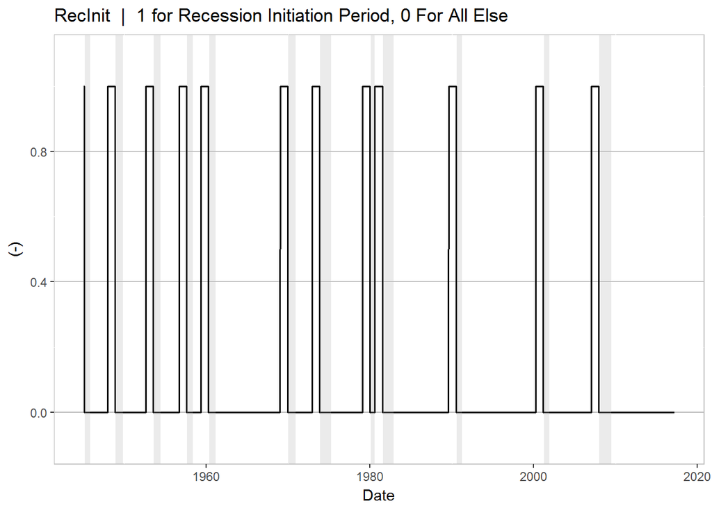

These are auxilliary series that will be used a bit later.

```r
dfData$UNRATE_Smooth <- sgolayfilt(dfData$UNRATE, p=3, n=21, m=0, ts=1)
dfSyms <- rbind(dfSyms, data.frame(Symbol="UNRATE_Smooth", Source="Calc",
              Desc="Smoothed Civilian Unemployment Rate U-3",
              yLabel="Percent" ))

dfData$UNRATE_SmoothDer2 <- sgolayfilt(dfData$UNRATE, p=3, n=501, m=2, ts=1)
dfSyms <- rbind(dfSyms, data.frame(Symbol="UNRATE_SmoothDer2", Source="Calc",
              Desc="2nd Derivative of Smoothed U-3",
              yLabel="Percent/period/period" ))

dfData$GSPC.OpenLog <- log(dfData$GSPC.Open)
dfSyms <- rbind(dfSyms, data.frame(Symbol="GSPC.OpenLog", Source="Calc",
              Desc="Log of S&P 500 Open",
              yLabel="log(Dollar)" ))

dfData$GSPC.OpenLog_SmoothDer <- sgolayfilt(dfData$GSPC.OpenLog, p=3, n=501, m=1, ts=1)
dfSyms <- rbind(dfSyms, data.frame(Symbol="GSPC.OpenLog_SmoothDer", Source="Calc",
              Desc="Derivative of Smoothed Log Scale S&P 500",
              yLabel="Dollar/period" ))

dfData$NCBDBIQ027S_Log <- log(dfData$NCBDBIQ027S)
dfSyms <- rbind(dfSyms, data.frame(Symbol="NCBDBIQ027S_Log", Source="Calc",
              Desc="Log Nonfinancial corporate business;\ndebt securities; liability, Level",
              yLabel="log(Millions of Dollars)" ))

dfData$NCBDBIQ027S_Log_Der <- sgolayfilt(dfData$NCBDBIQ027S_Log, p=3, n=501, m=1, ts=1)
dfSyms <- rbind(dfSyms, data.frame(Symbol="NCBDBIQ027S_Log_Der", Source="Calc",
              Desc="Derivative of Smoothed Log Nonfinancial corporate business; debt securities; liability, Level",
              yLabel="log(Milllons of Dollars)/period" ))


dfData$BUSLOANS_Log <- log(dfData$BUSLOANS)
dfSyms <- rbind(dfSyms, data.frame(Symbol="BUSLOANS_Log", Source="Calc",
              Desc="Log of Consumer and Industrial Loans",
              yLabel="log(Billlons of U.S. Dollars)" ))

dfData$BUSLOANS_Log_Der <- sgolayfilt(dfData$BUSLOANS_Log, p=3, n=501, m=1, ts=1)
dfSyms <- rbind(dfSyms, data.frame(Symbol="BUSLOANS_Log_Der", Source="Calc",
              Desc="Derivative of Smoothed Log Commercial and Industrial Loans",
              yLabel="log(Billlons of U.S. Dollars)/period" ))
```

# Data Exploration

There are some great plotting and visualization tools in the `quantmod` package, but for the prediction work `ggplot` will be used. This section walks through each of the data sets and notes features and relationships that would be helpful in building a trading strategy.

## S&P 500

One place to begin is with the relationship between stock prices and recessions. The predictor needs to be able to identify the onset of recession before the market declines. In theory, this predictor would give enough warning to cycle out of equity and into something more like cash or bonds. The plot below shows the S&P 500 open values in log-linear format. The market reaches a peak before most recessions, typically 6-9 months before the recession, shown by the blue rectangles in the plot below. A good predictor will correlate with the peak prior to an upcoming recession.

This section includes the plot code, but since the code is simple it is ommitted for the remainder of the plots.

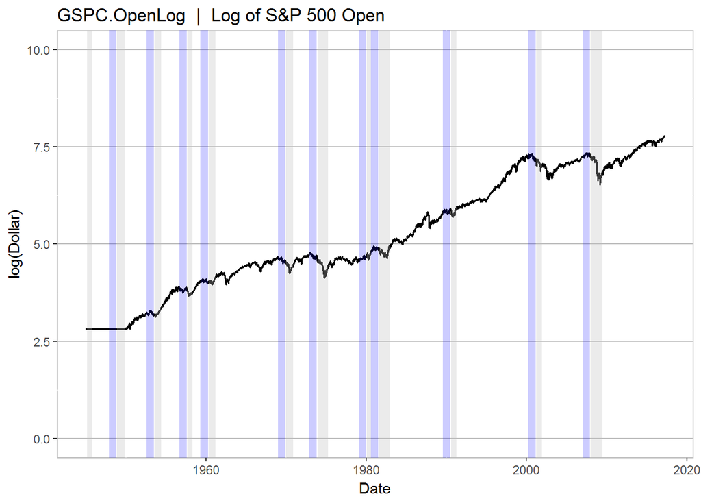

```r
datay <- "GSPC.OpenLog"
ylim <- c(0, 10)
myPlot <- plotSingleQuick(datay, ylim)
myPlot + geom_rect(data=dfRecession,  aes(xmin=initStart, xmax=initEnd, ymin=-Inf, ymax=Inf),
              fill="blue", alpha=0.2, na.rm = TRUE)
```

The features in the S&P curve that are most interesting are the peaks (where the sell signal should fall) and the troughs (where the buy signal should fall). One way to quantify the peaks is look at the derivative and see where it crosses zero. It looks like most of the positive to negative zero crossing fall in the blue regions where the recession indicator has been defined.

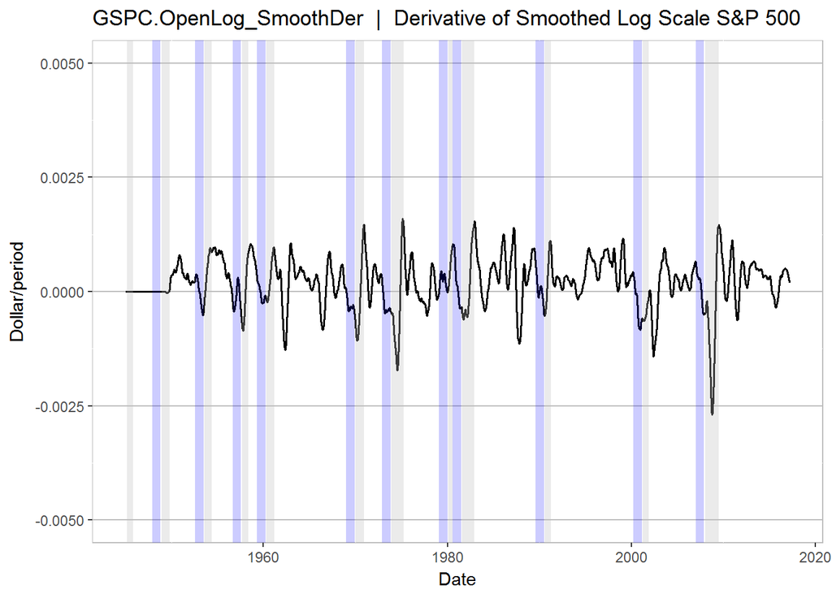

## Dividend Stocks

This is an interesting series, they should perform better through the recessions. Unfortunately they are short lived.

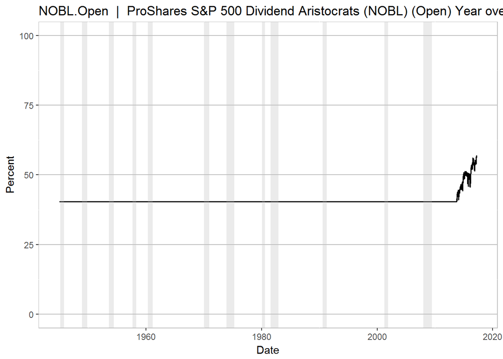

```r
datay <- "NOBL.Open"
ylim <- c(0, 100)
plotSingleQuick(datay, ylim)
```

## Unemployment rates

Unemployment rates will probably be useful, let’s take a look at the U-3. The data is a little noisy so there is also a smoothed version plotted. There seems to be a relationship between the unemployment rate and the recessions, but it could be a lagging indicator. This will be explored a little bit more later.

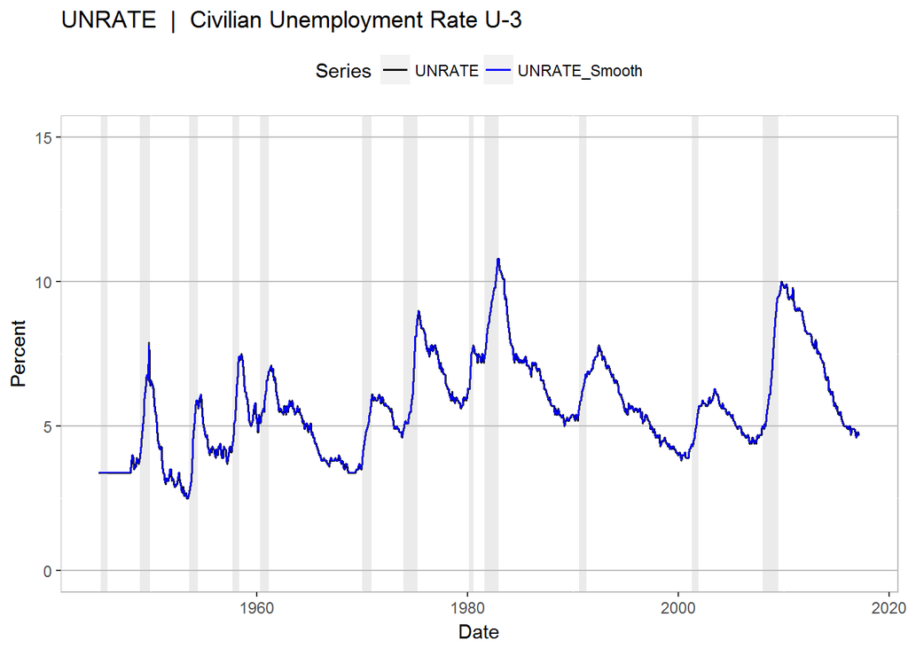

Looking at the unemployment rate, the eye is drawn to the rise and fall of the data, this suggests that the derivative might be helpful as well. The figure below shows the results, using a Savitzky-Golay FIR filter. It looks like the unemployment rate peaks in the middel of the recession. That peak might be a good buy signal.

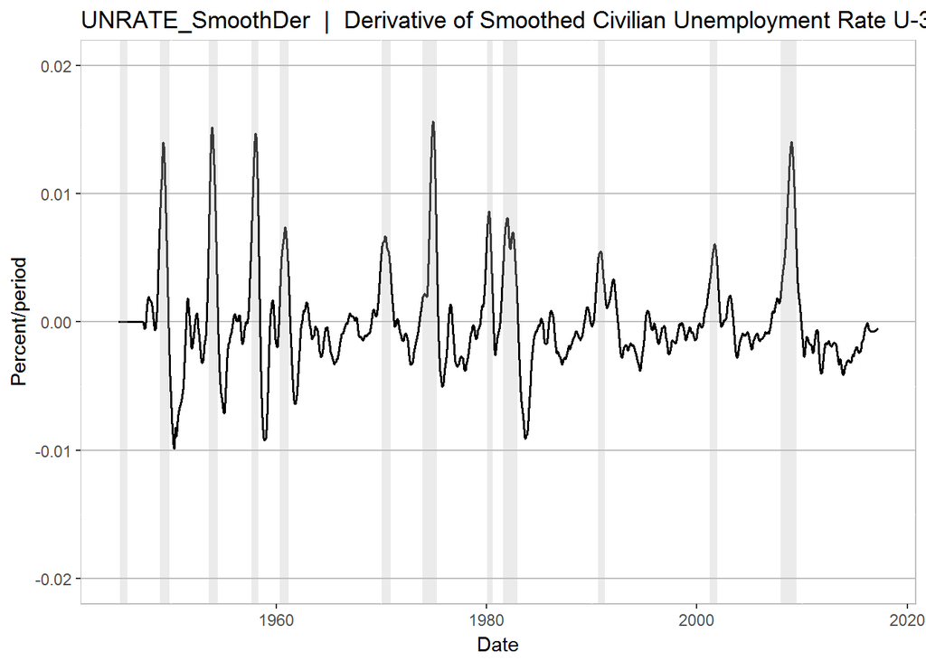

The second derivative of the unemployment rate does have zero crossings near the middle point of a recession. This would make it a helpful buy signal for the trading strategy.

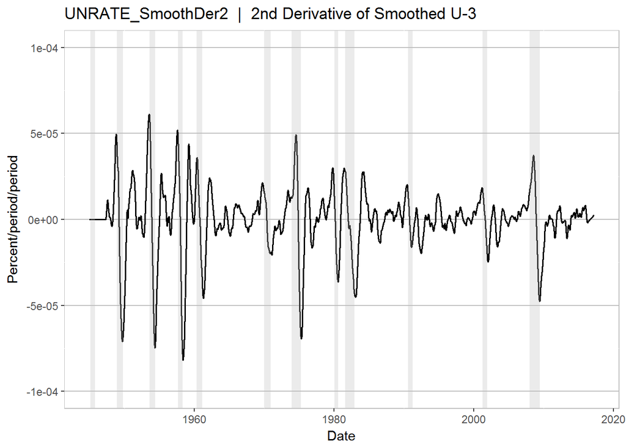

## Initial Jobless Claims

We will also take a look at initial jobless claims, this should start to rise just before the unemployment rate.

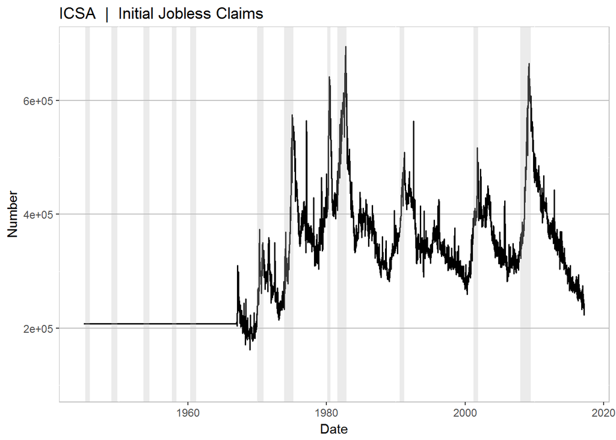

```r
datay <- "ICSA"
ylim <- c(100000, 700000)
plotSingleQuick(datay, ylim)
```

It looks like the jobless claim tend to peak more towards the end of the recession. It does not seem to be as strong of a sell indicator as the U-3 rate.

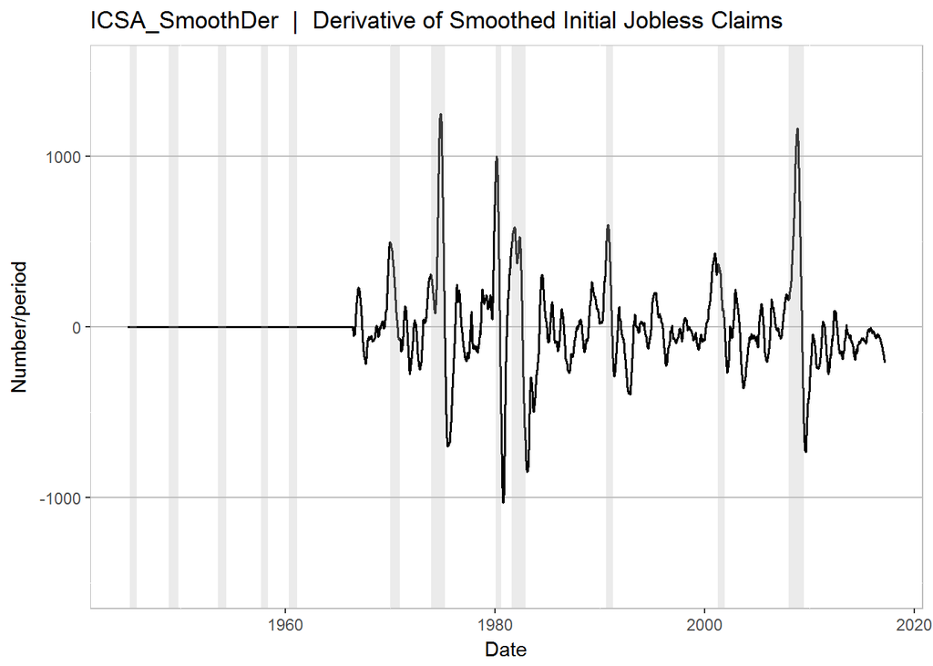

```r
datay <- "ICSA_SmoothDer"
ylim <- c(-1500, 1500)
plotSingleQuick(datay, ylim)
```

Jobless claims have a seasonal component to them. One way to reduce this effect is to calculate year over year growth. That helps some, the peaks seem to be more closely aligned with the middle to end of recessions.

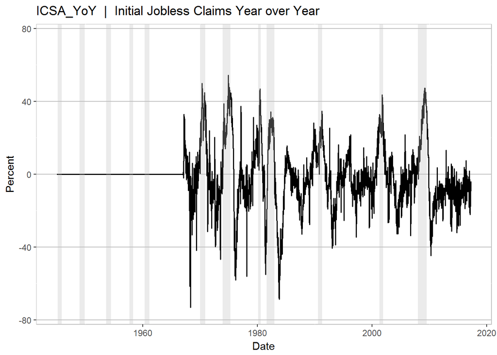

```r
datay <- "ICSA_YoY"
ylim <- c(-75, 75)
plotSingleQuick(datay, ylim)
```

## Industrial Production

Industrial production is also known to fall during an economic downturm, let’s take a look at some of the data from the FRED on industrual production. It does seem to peak prior to a recession so let’s smooth and look at the derivative as it might be a good indicator as well.

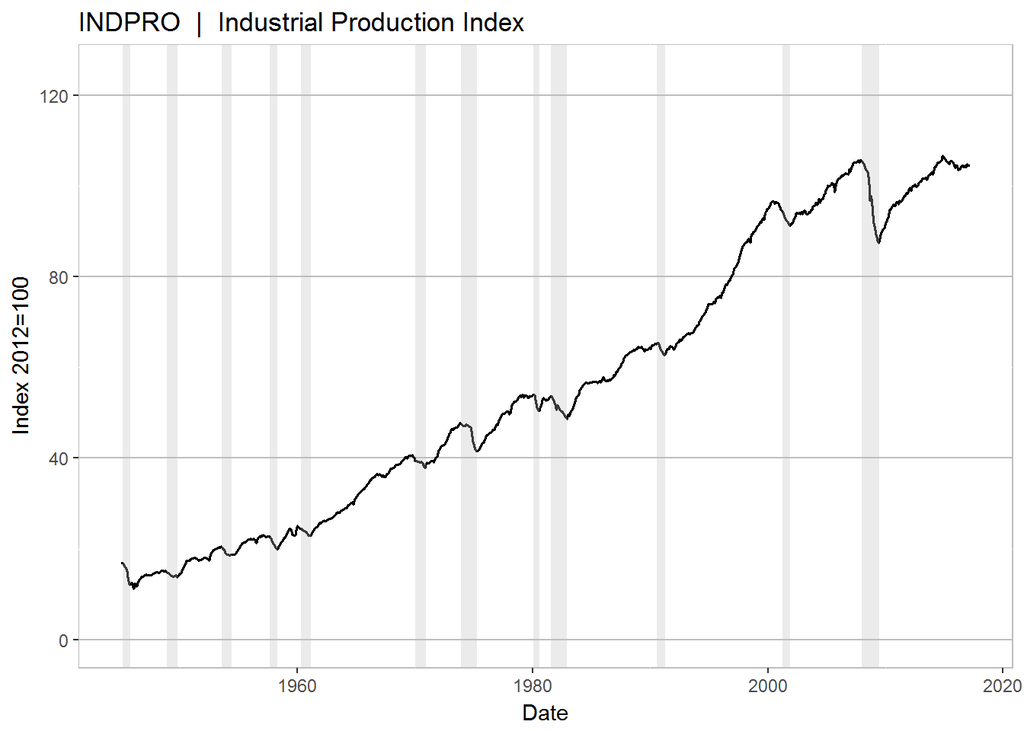

The derivative isn’t bad, but it sometimes crosses zeros well into a recession. That is less helpful as either a buy or sell indicator. A better measure might year over year (YoY) change.

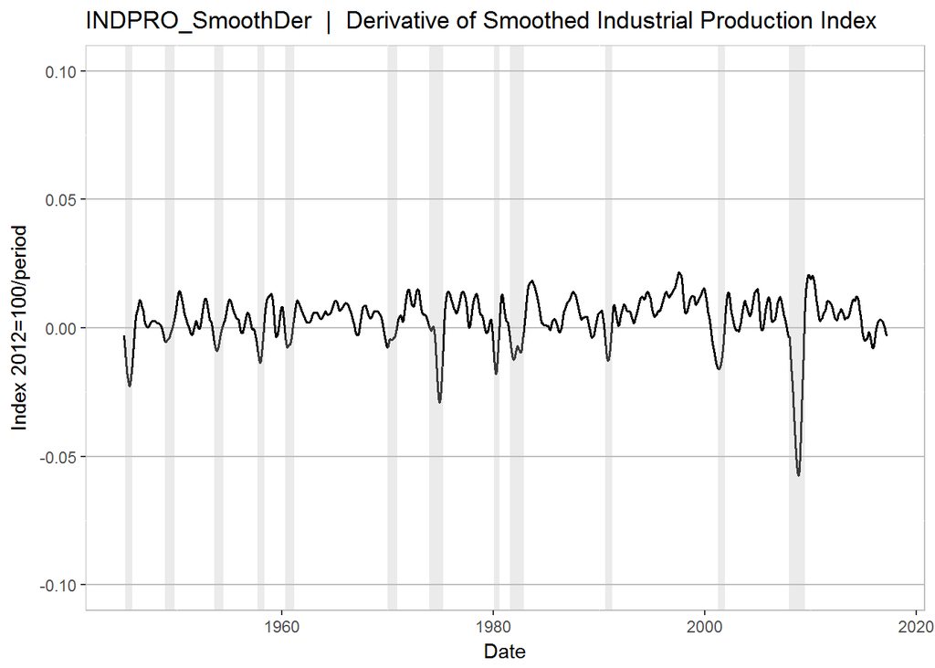

The year over year change has a similar appearance. The low values at the beginning make the year over year values larger than the more recent values. Seems like it will rank low a reliable indicator.

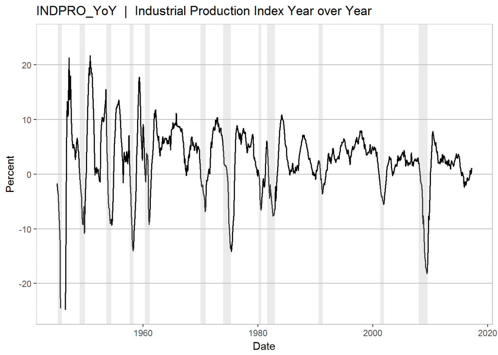

## Retail Sales

Retail sales also change during recession. As the plot below shows, it seems to follow the trend of industrial production. It might be too strongly correlated to add much to the model. The will be examined in the correlation section.

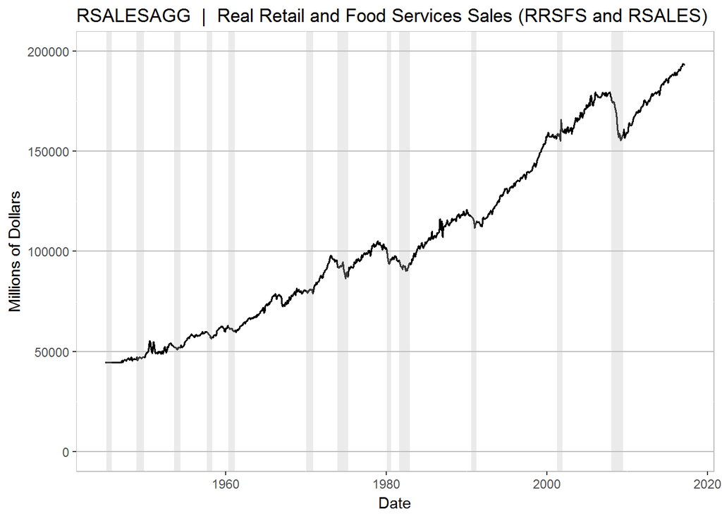

The derivative of retail sales is a little more erratic than is was the industrial products. Looks like it might be helpful to include in the model as well.

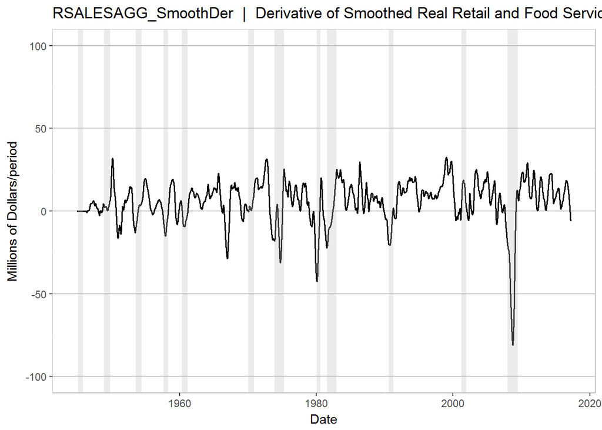

## Real Personal Income

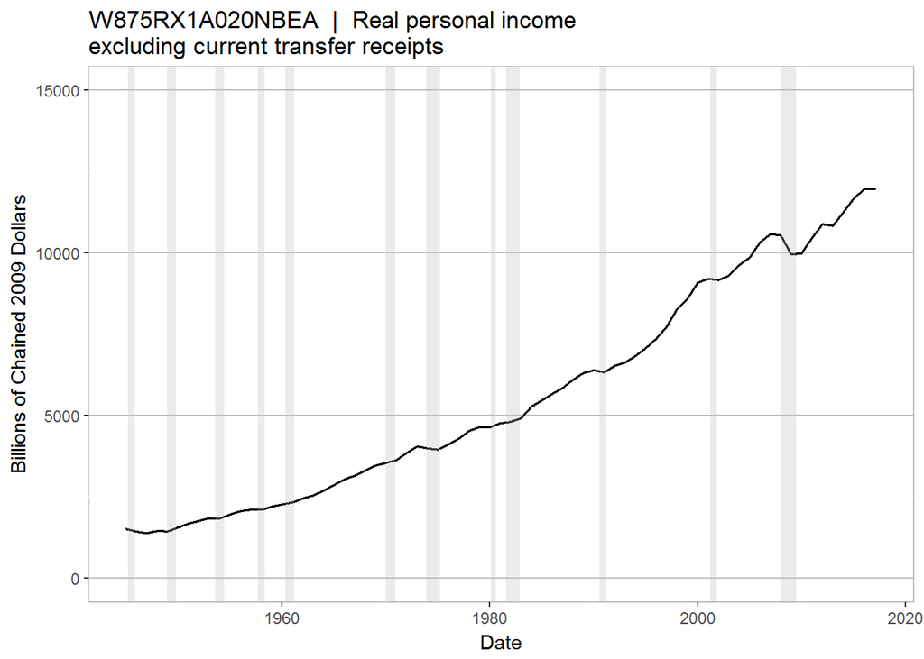

The features we are interested in are the peaks and valleys so we’ll use the derivative to get to those. Interesting, there is usually a first zero crossing before a recession and a second during or just after the recession.

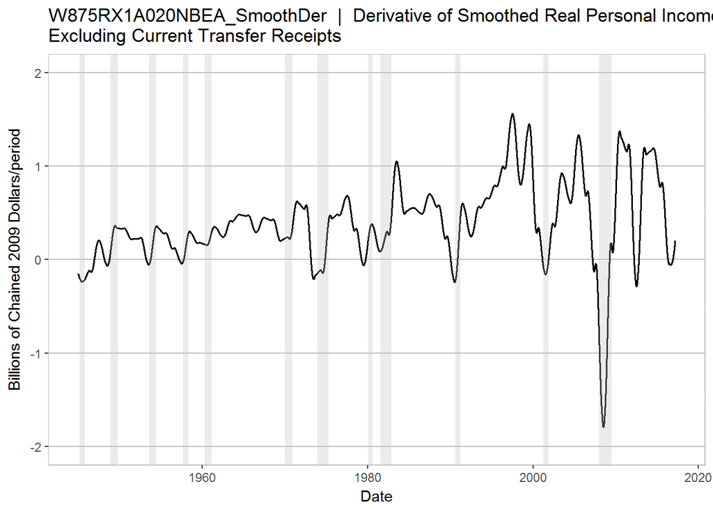

Real personal income might have some seasonal variance, but it seems the year over year change tells the same story.

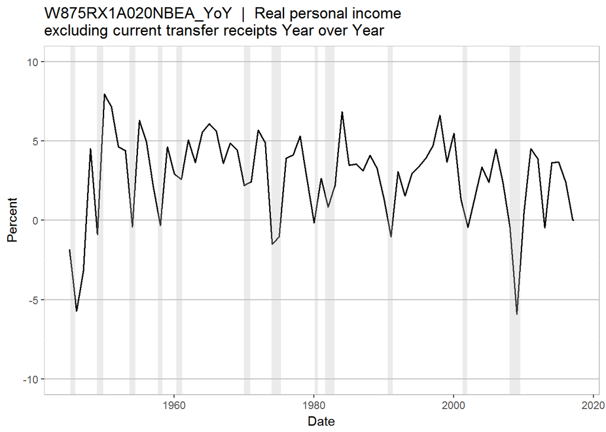

## Copper

Dr. Copper has a reputation as an indicator of economic malaise, but it does not seem to have much of a correlation with the recessions.

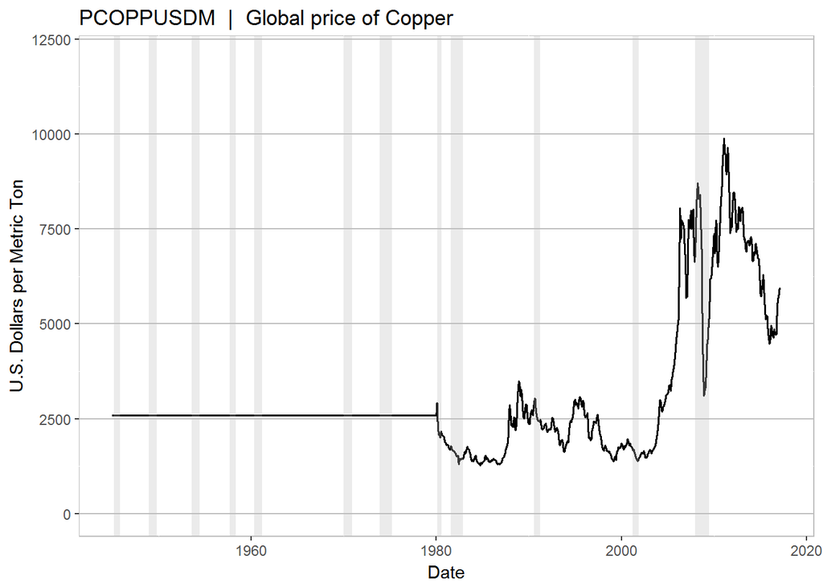

I also took a look at the derivative, but it doesn’t seem to have much of a correlation either.

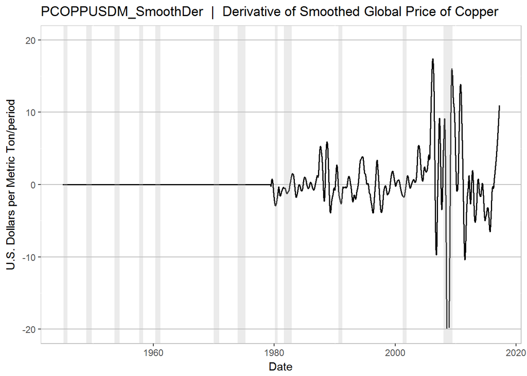

## Business Loans

Business loans should slow before the recession (a contraction in credit as rates rise).

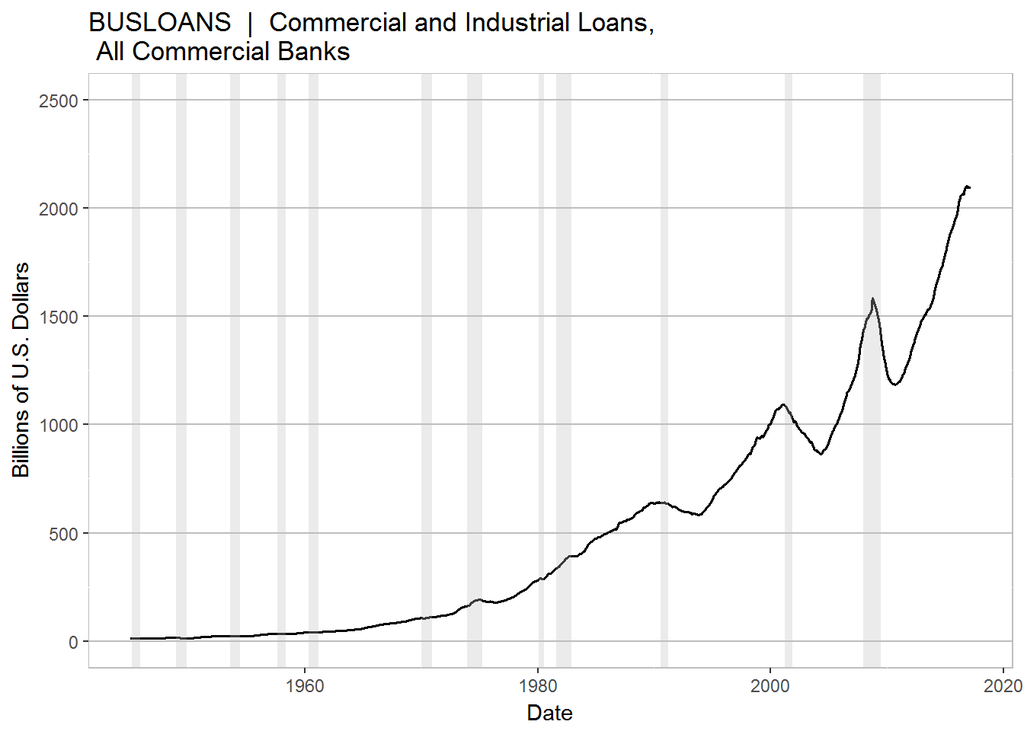

That is just too steep for any kind of machine learnine. This needs to be converted to log scale.

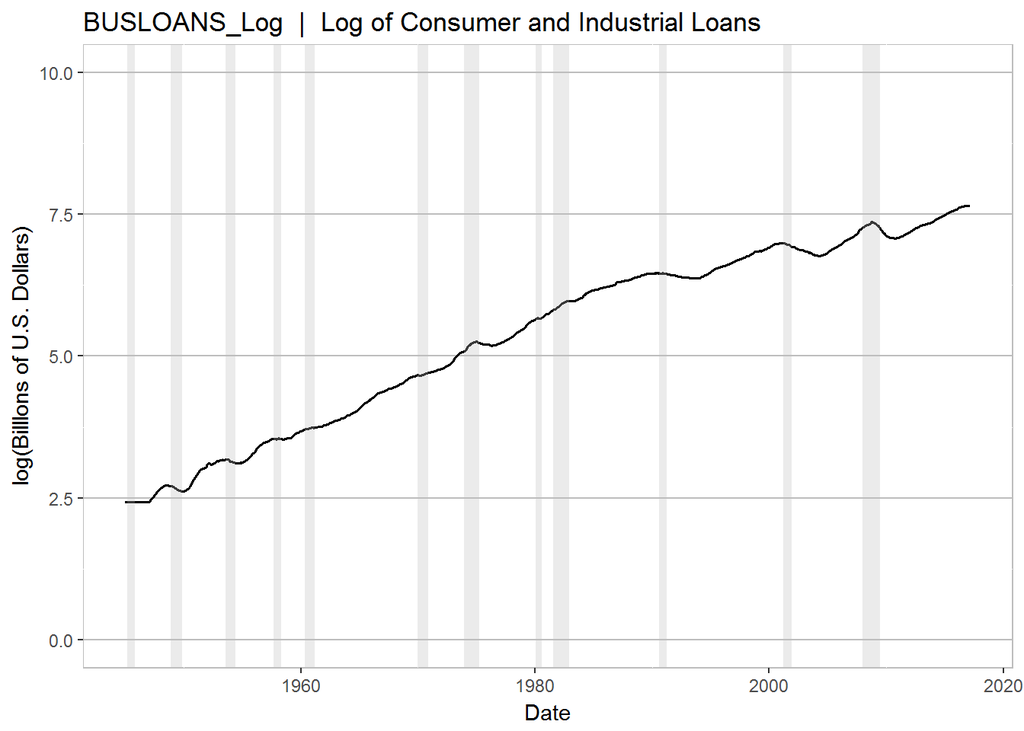

That’s a little better, let’s see what the smoothed derivative looks like.

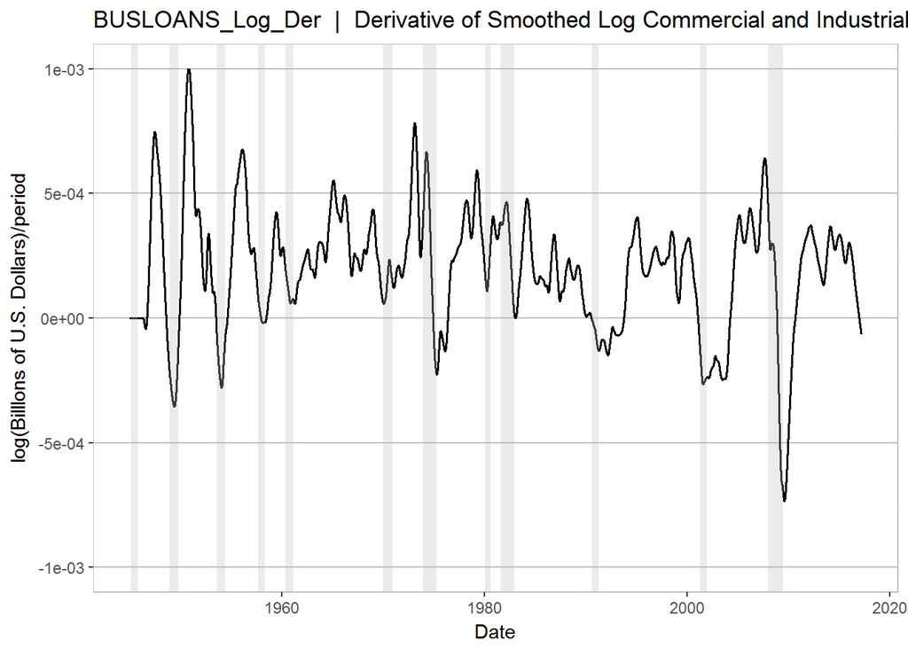

That is odd…looks like this doesn’t cross zero unless we are getting close to, or into, a recession. The year over year tells about the same story.

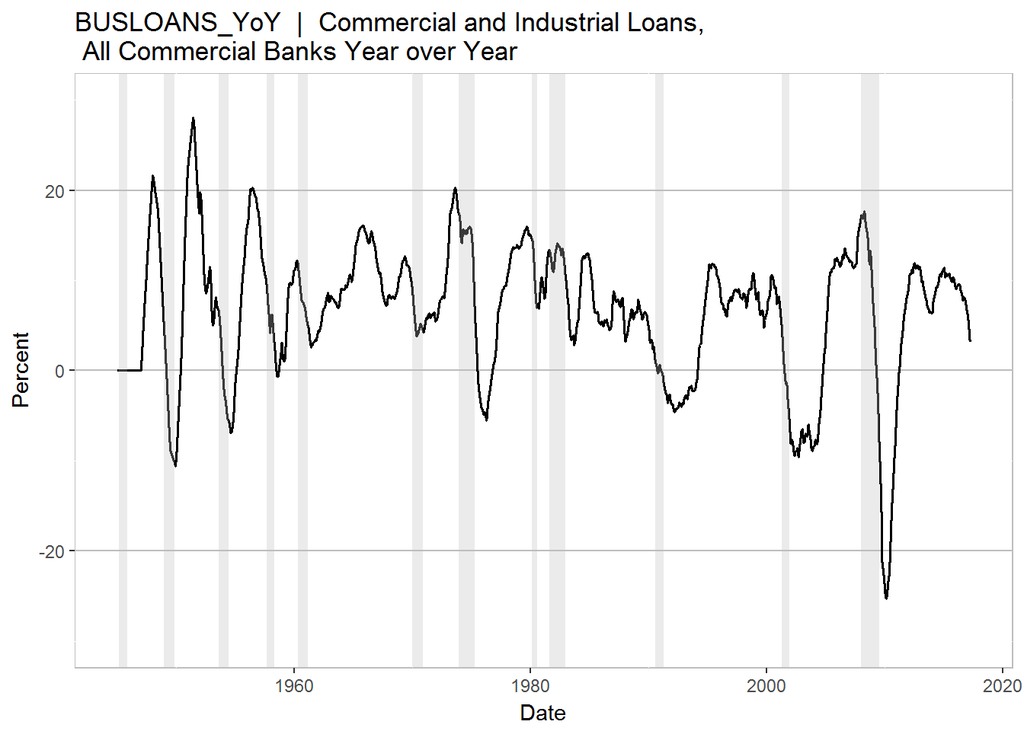

## Nonfinancial Corporate Business Debt

What about Nonfinancial corporate business and debt securities? Hopefully this doesn’t follow the business loan trends.

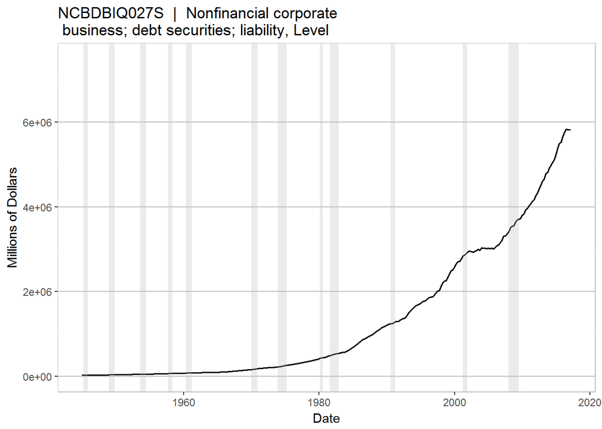

That is crazy steep. Time for a log format, see if that brings out the peaks and troughs. That’s a litte better, it looks like there might be a change in slope prior to the recessions.

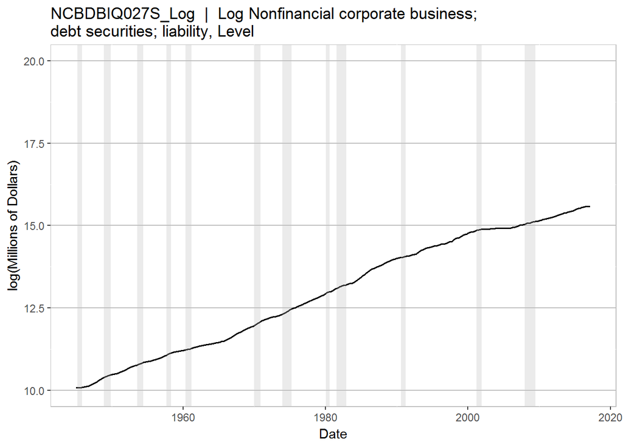

The derivative doesn’t seem to be much help. There is not much correlation between the zero crossings and the NEBR recessions.

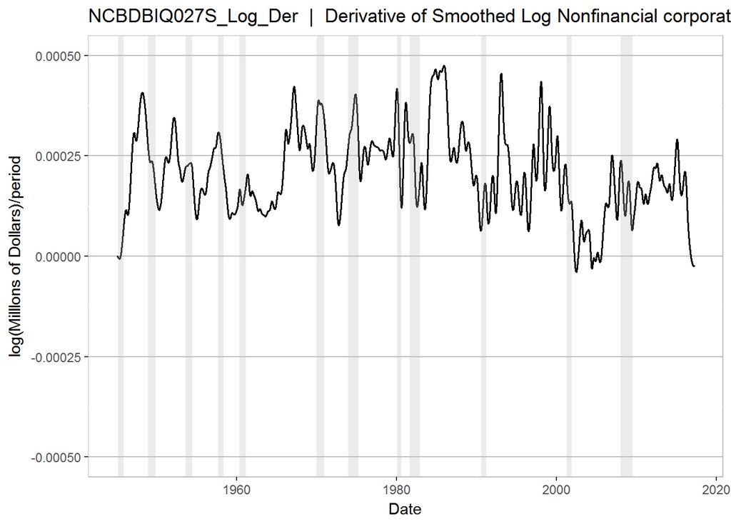

## Total Loans

One business cycle theory describes recessions as a market adjustment to mis-allocated assets, often fueled by an credit expansion. That makes the volume of loans an interesting feature to look at. In the presentation of data it looks like the great recession had the largest impact.

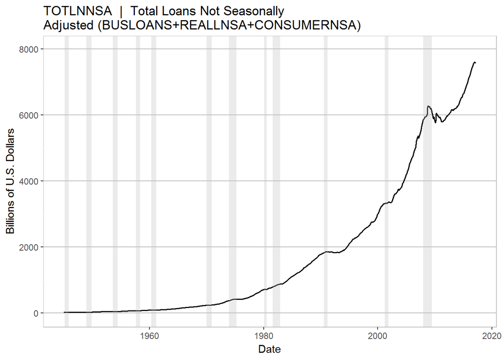

Plotting the year over year growth rate helps pull out those small changes in the early years in the data. Peaks can be seen prior to most recessions.

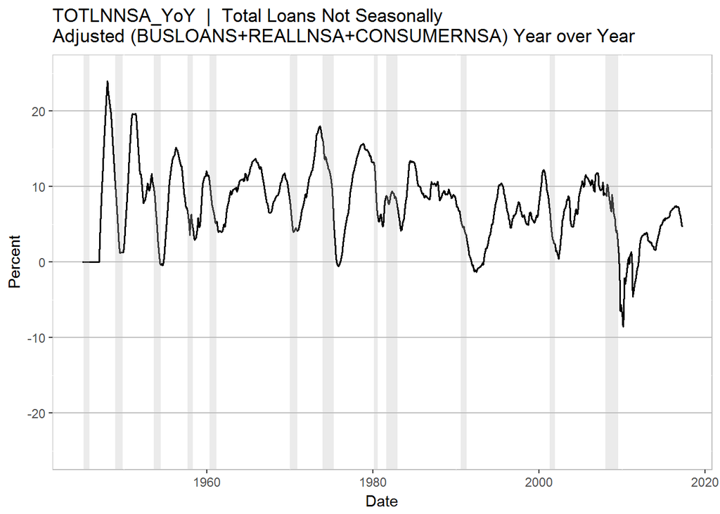

## T-Bills and Yield Curve

Speaking of loans, interest rates also play into this. This analysis will focus on treasure bills. The 1-year is plotted below. The yield flattens before a recession as investors go long on bonds and short on equities.

[figure not shown]

```r
datay <- "DGS1"
ylim <- c(0, 20)
p1 <- plotSingleQuick(datay, ylim)
p1
```

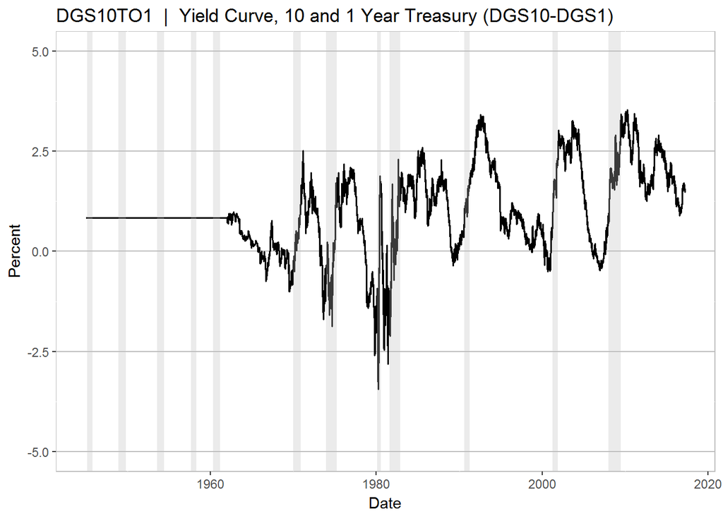